# Loading the Data

### Evaluate the Model Using Test Data from 2013-2015

After evaluating the model using the test data from 2013-2015, the following can be derived:

Confusion Matrix

87,900 True Negatives: Correctly predicted loans that were fully paid.

Performance Metrics

Accuracy 81.3%: The model correctly classifies 81.3% of the loans in this test set.

ROC Curve & AUC

AUC 0.705: On average, the model has a 70.5% chance of distinguishing between a loan that gets charged off and one that is fully paid. Overall, this model has a moderate ability to distinguish between charged off and fully paid loans when applied to unseen data from 2013-2015.

```r
#libraries
library(caret)
library(pROC)

#Predict on test data
log_predict <- predict(log_model, test_data, type = "response")

#Convert Probabilities to Class
log_predict_class <- ifelse(log_predict > 0.5, 1, 0)

#Covert Predicted and Actual to Factors with Same Levels
log_predict_class <-factor(log_predict_class, levels = c(0,1)) # Predicted Classes
test_data$loan_status <-factor(test_data$loan_status, levels = c(0,1)) # Actual Classes

#Confusion Matrix
con_matrix <- confusionMatrix(as.factor(log_predict_class), test_data$loan_status)
print(con_matrix)
```

```
## Confusion Matrix and Statistics
##
##           Reference
## Prediction     0     1
##          0 87900 19849
##          1   529   527
##
##                Accuracy : 0.813
##                  95% CI : (0.81, 0.815)
##     No Information Rate : 0.813
##     P-Value [Acc > NIR] : 0.508
##
##                   Kappa : 0.031
##
##  Mcnemar's Test P-Value : <2e-16
##
##             Sensitivity : 0.9940
##             Specificity : 0.0259
##          Pos Pred Value : 0.8158
##          Neg Pred Value : 0.4991
##              Prevalence : 0.8127
##          Detection Rate : 0.8079
##    Detection Prevalence : 0.9903
##       Balanced Accuracy : 0.5099
##
##        'Positive' Class : 0
##
```

```r
#ROC Curve and AUC
roc_curve <-roc(test_data$loan_status, as.numeric(log_predict))
auc_value <- auc(roc_curve)
print(auc_value)
```

```
## Area under the curve: 0.705
```

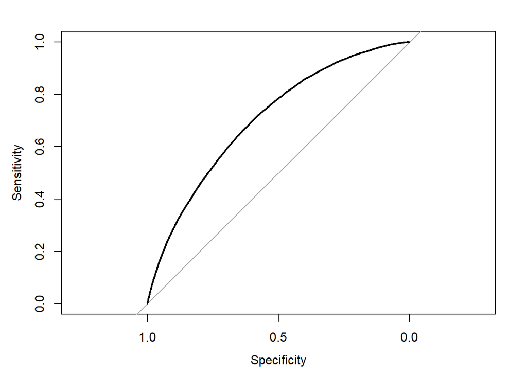

```r
plot(roc_curve)
```

Confusion Matrix

60,146 True Negatives: Correctly predicted loans that were fully paid.

Performance Metrics

Accuracy 77.4%: The model correctly classifies 77.4% of the loans in this test set.

```r
#libraries
library(caret)
library(pROC)

#Predict on test data
log_predict_2 <- predict(log_model, test_data_2, type = "response")

#Convert Probabilities to Class
log_predict_class_2 <- ifelse(log_predict_2 > 0.5, 1, 0)

#Covert Predicted and Actual to Factors with Same Levels
log_predict_class_2 <-factor(log_predict_class_2, levels = c(0,1)) # Predicted Classes
test_data_2$loan_status <-factor(test_data_2$loan_status, levels = c(0,1)) # Actual Classes

#Confusion Matrix
con_matrix_2 <- confusionMatrix(as.factor(log_predict_class_2), test_data_2$loan_status)
print(con_matrix_2)
```

```
## Confusion Matrix and Statistics
##
##           Reference
## Prediction     0     1
##          0 60146 17415
##          1   188   177
##
##                Accuracy : 0.774
##                  95% CI : (0.771, 0.777)
##     No Information Rate : 0.774
##     P-Value [Acc > NIR] : 0.54
##
##                   Kappa : 0.011
##
##  Mcnemar's Test P-Value : <2e-16
##
##             Sensitivity : 0.9969
##             Specificity : 0.0101
##          Pos Pred Value : 0.7755
##          Neg Pred Value : 0.4849
##              Prevalence : 0.7742
##          Detection Rate : 0.7718
##    Detection Prevalence : 0.9953
##       Balanced Accuracy : 0.5035
##
##        'Positive' Class : 0
##
```

```r
#ROC Curve and AUC
roc_curve_2 <-roc(test_data_2$loan_status, as.numeric(log_predict_2))
auc_value_2 <- auc(roc_curve_2)
print(auc_value_2)
```

```
## Area under the curve: 0.696
```

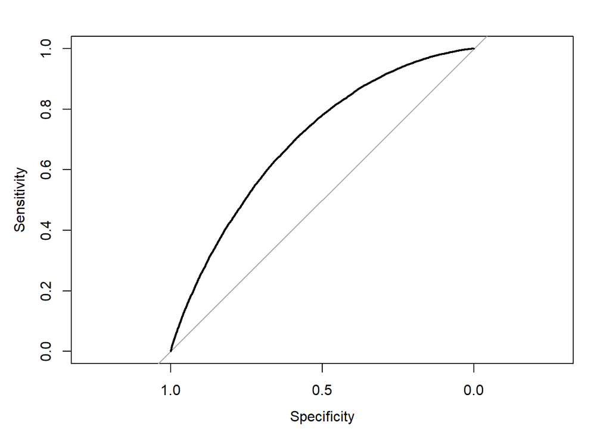

```r
plot(roc_curve_2)
```

# 3. How accurately can we predict loan charge-offs for Lending Club loans issued between 2015-2018 that are still active and might charge-off in future, using our 2013-2018 trained models from Question #2?

## Logistic Regression Model

After using 2013-2018 data to train the logistic regression model, we can then use this model to predict how much active loans from 2015-2018 will charge off. After predicting probabilities and using a probability threshold of 0.5, the model predicts that there’s a higher than 50% risk of 115,242 active loans being charged off. On the other hand, the model predicts that there’s a 50% or lower risk of 748,371 active loans being charged off.

When comparing it to the 0.7 threshold, the 0.5 threshold is more lenient, meaning the model classifies loans as charged off when the probability of being charged off is greater than 50%. Whereas, the 0.7 is stricter requiring a charged off probability greater than 70% for the loan to be classified as charged off. This is why there are less charged off instances with the 76,601 number compared to 115,242.

### 0.5 Probabability Threshold For Predicting Charge-Offs Table

```r
#library
library(dplyr)
#Train Logistic Regression Model using 2013-2018 trained data
active_model <-glm(loan_status ~ loan_amnt + int_rate + grade + sub_grade + dti + emp_length + last_fico_range_high + last_fico_range_low + fico_range_low + fico_range_high + open_acc_6m + annual_inc, data = all_train_data, family = binomial)

#Predict Probabilities
active_data$predicted_prob <-predict(active_model, newdata = active_data, type = "response")

#Classify loans based on probability threshold
active_data <-active_data %>%
  mutate(predicted_risk = ifelse(!is.na(predicted_prob) & predicted_prob > 0.5, "Charged Off", "Fully Paid"))

#Summary of Predicted Charge-Offs
table(active_data$predicted_risk)
```

```
##
## Charged Off  Fully Paid
##      115242      748371
```

### 0.7 Probabability Threshold For Predicting Charge-Offs Table

```r
#Classify loans based on probability threshold
active_data <-active_data %>%
  mutate(predicted_risk = ifelse(!is.na(predicted_prob) & predicted_prob > 0.7, "Charged Off", "Fully Paid"))

#Summary of Predicted Charge-Offs
table(active_data$predicted_risk)
```

```
##
## Charged Off  Fully Paid
##       76601      787012
```